# Analyzing fordgobike trip data

## by Abdulaziz alsheddi

### Preliminary Wrangling

- ### This data contains good business featrues, to facilitate detection of problems and increase opportunities for improvement and development

### What is the structure of your dataset?

> About the data structure, the data was almost clean but there were missing values in only some rows and also I added some columns to help in extracting the knowledge from it.

### What is/are the main feature(s) of interest in your dataset?

> the main featrues that i will foucs on them are duration_sec and start_station_name and member_birth_year

### What features in the dataset do you think will help support your investigation into your feature(s) of interest?

> added some columns to help like month and user_age and duration_hour

### We will see which month there are more bike rental operations

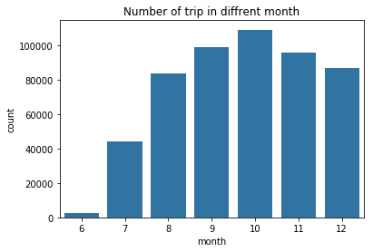

- ### As we see, the most month in which bike rental operations occurred is month 10, and we have a weakness in month 6 ??

### Here we will see which station has the most rental bicycles ?

[figure not shown]

### here we want to cheak our destrebution for ages of our customer and destrebution of duration in hours

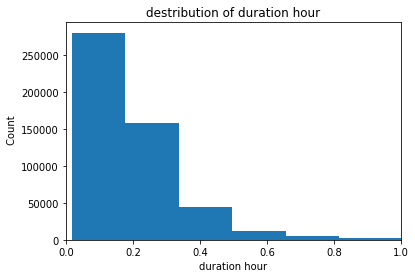

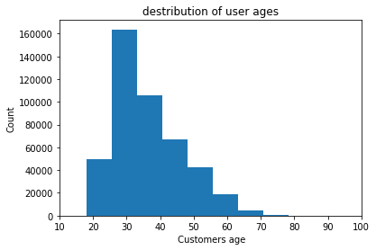

### Bivariate Exploration

#### In this section, investigate relationships between pairs of variables in your data. Make sure the variables that you cover here have been introduced in some fashion in the previous section (univariate exploration).

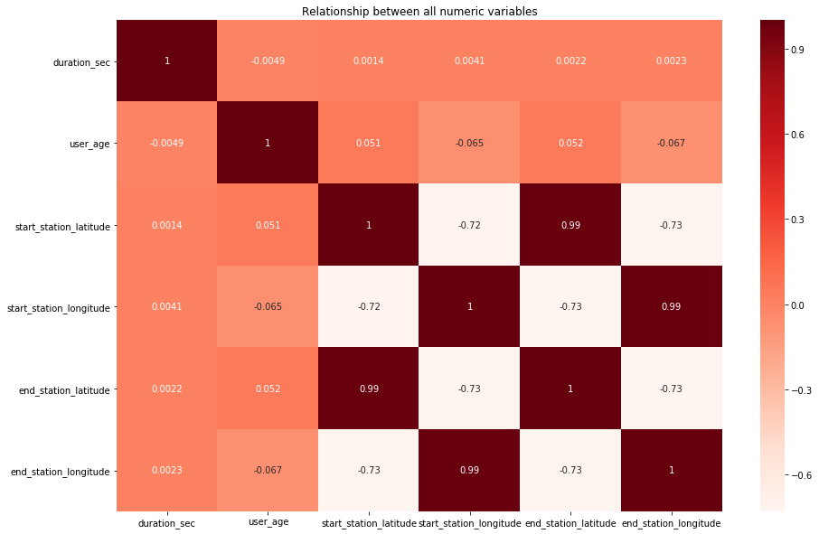

### Here we want to see which month happened, more practical to hire, separate customers and subscribers

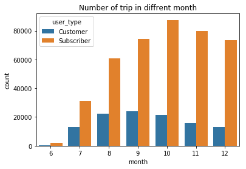

### We also saw that in Month 10 was the most leasing operation from subscribers, and in Month 9 it was the most leasing operation from customer and also ew noticed that we have A large number of subscribers compared to the number of customers

### Here we will see the concentration of data for men and women with the time period

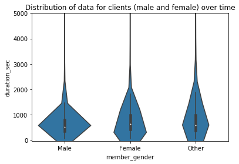

### Did you observe any interesting relationships between the other features (not the main feature(s) of interest)?

- there is a strong relationship between months and amount of trips

### Multivariate Exploration

> Create plots of three or more variables to investigate your data even further. Make sure that your investigations are justified, and follow from your work in the previous sections.

#### Now we want to see the relationship and the distribution of data between seconds and ages of people, and the division of data into customers and subscribers

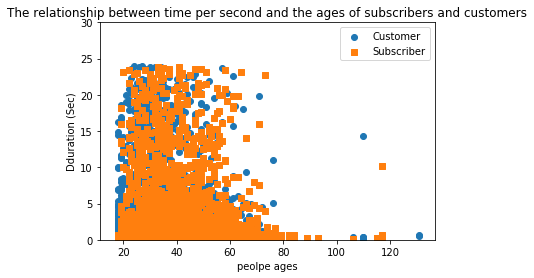

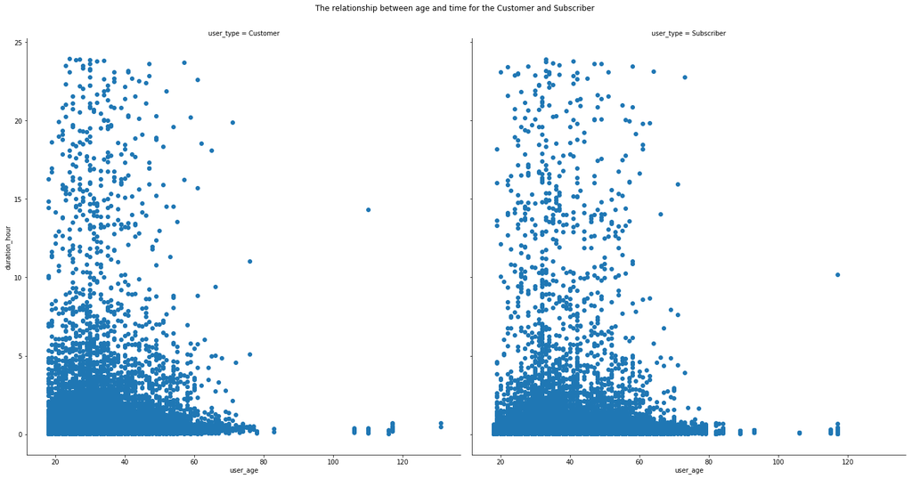

### Now we will add a new column that helps us extract more information. This column will be specific to days of the week, and we will see which days of the week there are people They were spending more time, and we will divide the people except for subscribers and customers

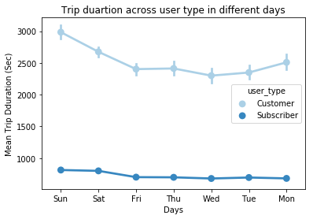

### Were there any interesting or surprising interactions between features?

#### we found that sunday is most day people have spent time